# N-Pact Factor assessment for IRAP research

Ian Hussey

09 January, 2023

# Notes of differences between original Fraley et al. analysis and my reanalysis

Limited to between-only designs. NB original Fraley et al. (2022) study used only between-groups studies in the tables but plotted all studies. Here I use all between groups social psych studies and both between and mixed IRAP studies, as all mixed IRAP studies also reported between analyses.

# Dependencies

```r
library(pwr)
library(tidyverse)
library(janitor)
library(viridis)
library(knitr)
library(kableExtra)
library(bayestestR)
library(scales)
```

# Data

```r
data_combined <- read_csv("../data/processed/data_fraley_and_irap.csv") |>
  rename(N = n_participants_after_exclusions,
         design = study_design_ignoring_trial_type_comparisons) |>
  mutate(year = str_replace(publication_year, "20", "'"),
         field = ifelse(journal == "IRAP", "IRAP research", "Social Psychology"),
         design = case_when(design == "b" ~ "between",
                            design == "w" ~ "within",
                            design == "m" ~ "mixed"))
```

# IRAP studies sample size

## Full sample descriptives

```r
data_irap_n <-
  data_combined |>
  filter(journal == "IRAP") |>
  drop_na(N)

k_articles <- data_irap_n |>
  distinct(key) |>
  count() |>
  pull(n)

k_studies <- data_irap_n |>
  count()  |>
  pull(n)

MAP <- bayestestR::map_estimate(data_irap_n$N) |>
  janitor::round_half_up(1) |>
  as.numeric()

data_irap_n |>
  summarize(`Total articles` = k_articles,
            `Total studies` = k_studies,
            `Total N` = sum(N),
            Median = median(N),
            MAD = janitor::round_half_up(mad(N), 1),
            Min = min(N),
            Max = max(N)) |>
  mutate(MAP = MAP) |>
  select(`Total articles`,
         `Total studies`,
         `Total N`,
         `MAP N` = MAP,
         `Median N` = Median,
         `MAD N` = MAD,
         `Min N` = Min,
         `Max N` = Max) |>
  kable() |>
  kable_classic(full_width = FALSE)
```

| Total articles | Total studies | Total N | MAP N | Median N | MAD N | Min N | Max N |
| --- | --- | --- | --- | --- | --- | --- | --- |
| 153 | 188 | 8419 | 34.8 | 40 | 17.8 | 4 | 210 |

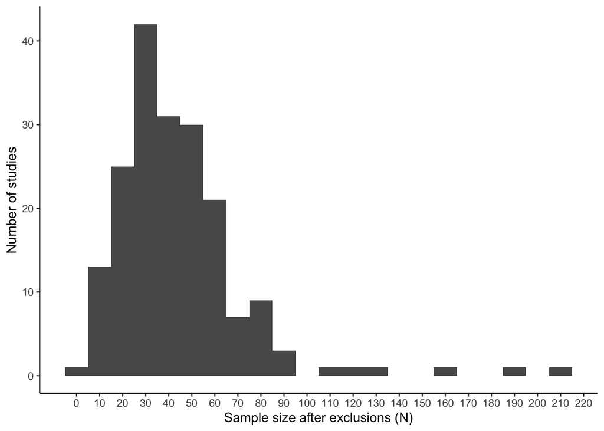

```r
ggplot(data_irap_n, aes(N)) +
  geom_histogram(binwidth = 10) +
  theme_classic() +
  ylab("Number of studies") +
  xlab("Sample size after exclusions (N)") +
  scale_x_continuous(breaks = seq(from = 0, to = 250, by = 10))
```

## Split by study design

Note that IRAP publications with mixed designs also report results from between groups analyses, and so both mixed and between are included in the power analyses further sections below.

```r
data_combined |>
  filter(!is.na(N) & journal == "IRAP") |>
  distinct(title, design) |>
  count(design) |>
  mutate(percent = janitor::round_half_up(n/sum(n), 2)) |>
  kable() |>
  kable_styling(bootstrap_options = c("striped", "hover", "condensed"), full_width = FALSE)
```

| design | n | percent |
| --- | --- | --- |
| between | 73 | 0.48 |
| mixed | 32 | 0.21 |
| within | 48 | 0.31 |

## Change over time

### Table

```r
data_irap_n_per_study <- data_combined |>
  filter(field == "IRAP research")

# Filter out non-social studies published in psych science
data_table_1_filtered <- data_irap_n_per_study |>
  filter(field == "IRAP research")

# calculate median N for each field and year
# round using typical half-up rule and not R's weird rounding
data_table_1_n_long <- data_table_1_filtered |>
  group_by(field, year) |>
  summarize(median_n = janitor::round_half_up(median(N, na.rm = TRUE), 0)) |>
  ungroup()

# Calculate median median n for each field
data_table_1_n_aggregate <- data_table_1_n_long |>
  group_by(field) |>
  summarize(median_median_n = median(median_n, na.rm = TRUE)) |>
  ungroup()

# Calculate k studies used to calculate median ns
data_table_1_k_long <- data_table_1_filtered |>
  count(field, year, name = "k_studies")

# combine Ns and Ks, reshape, and order field column by aggregate median median n
data_table_1 <-
  full_join(data_table_1_n_long, data_table_1_k_long, by = c("field", "year")) |>
  mutate(result = paste0(median_n, " (", k_studies, ")")) |>
  select(-median_n, -k_studies) |>
  pivot_wider(names_from = year,
              values_from = result) |>
              #names_prefix = "NF ") |>
  left_join(data_table_1_n_aggregate, by = "field") |>
  mutate(field = fct_reorder(field, median_median_n)) |>
  arrange(desc(field)) |>
  select(field, median_median_n,
         `'06`, `'07`, `'08`, `'09`, `'10`, `'11`,
         `'12`, `'13`, `'14`, `'15`, `'16`, `'17`,
         `'18`, `'19`, `'20`, `'21`, `'22`)

# print table
data_table_1 |>
  select(field,
         Aggregate = median_median_n,
         starts_with("'")) |>
         #starts_with("NF")) |>
  kable() |>
  kable_styling(bootstrap_options = c("striped", "hover", "condensed"), full_width = FALSE)
```

| field | Aggregate | ’06 | ’07 | ’08 | ’09 | ’10 | ’11 | ’12 | ’13 | ’14 | ’15 | ’16 | ’17 | ’18 | ’19 | ’20 | ’21 | ’22 |
| --- | --- | --- | --- | --- | --- | --- | --- | --- | --- | --- | --- | --- | --- | --- | --- | --- | --- | --- |
| IRAP research | 36 | 14 (4) | 36 (1) | 12 (2) | 29 (10) | 28 (10) | 62 (6) | 26 (7) | 37 (8) | 32 (9) | 41 (16) | 43 (30) | 32 (17) | 44 (15) | 36 (20) | 50 (16) | 41 (11) | 64 (7) |

### Figure

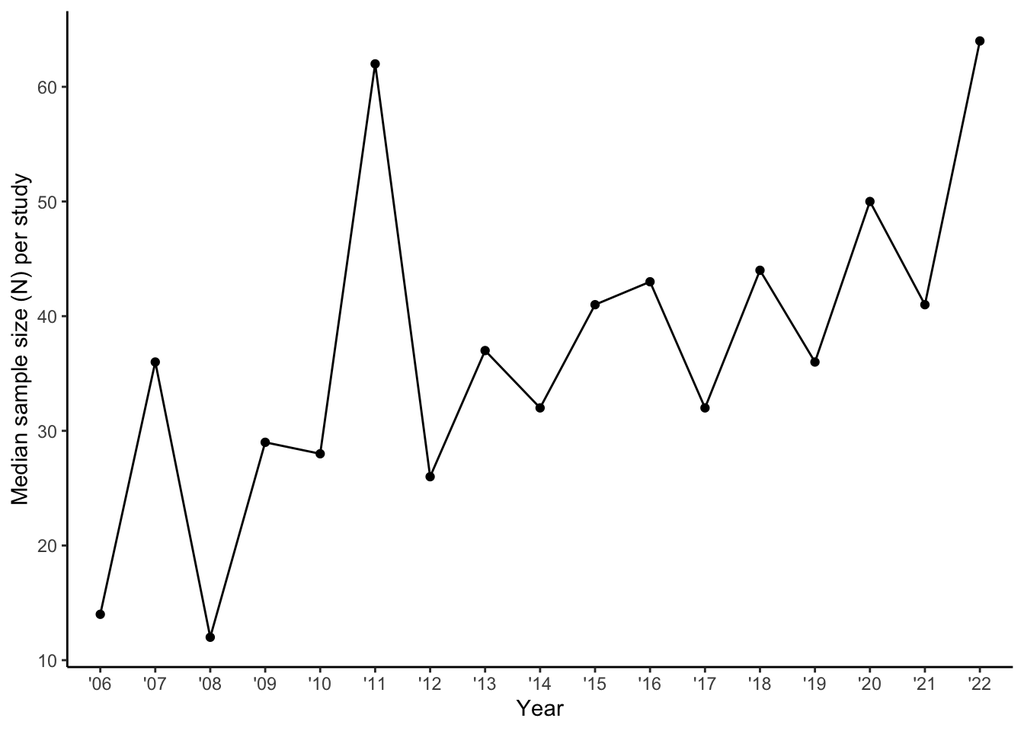

```r
# Filter out non-social studies published in psych science
# calculate median Ns
# order field column by same used in Table 1
data_figure_1 <- data_irap_n_per_study |>
  filter(journal == "IRAP") |>
  group_by(field, year) |>
  summarize(median_n = janitor::round_half_up(median(N, na.rm = TRUE), 0)) |>
  ungroup() |>
  mutate(field = fct_rev(fct_relevel(field, levels(data_table_1$field))))

# plot
ggplot(data_figure_1, aes(as.factor(year), median_n, group = field)) +
  #geom_smooth(method = "lm") +
  geom_line() +
  geom_point() +
  scale_color_viridis_d(option = "plasma", begin = 0.1, end = 0.9) +
  theme_classic() +
  ylab("Median sample size (N) per study") +
  xlab("Year")
```

# IRAP studies sample size by cell

## Change in N-pact over time

Results represent Median N (k studies)

### Table

```r
# Filter out non-social studies published in psych science
data_table_2_filtered <- data_combined |>
  filter(journal == "IRAP" & design %in% c("between", "mixed")) |>
  mutate(N_per_cell = N/n_groups_between)

# calculate median N for each field and year
# round using typical half-up rule and not R's weird rounding
data_table_2_n_long <- data_table_2_filtered |>
  group_by(field, year) |>
  summarize(median_n_per_cell = janitor::round_half_up(median(N_per_cell, na.rm = TRUE), 0)) |>
  ungroup()

# Calculate median median n for each field
data_table_2_n_aggregate <- data_table_2_n_long |>
  group_by(field) |>
  summarize(median_median_n_per_cell = median(median_n_per_cell, na.rm = TRUE)) |>
  ungroup()

# Calculate k studies used to calculate median ns
data_table_2_k_long <- data_table_2_filtered |>
  count(field, year, name = "k_studies")

# combine Ns and Ks, reshape, and order field column by aggregate median median n
data_table_2 <-
  full_join(data_table_2_n_long, data_table_2_k_long, by = c("field", "year")) |>
  mutate(result = paste0(median_n_per_cell, " (", k_studies, ")")) |>
  select(-median_n_per_cell, -k_studies) |>
  pivot_wider(names_from = year,
              values_from = result) |>
              #names_prefix = "NF ") |>
  left_join(data_table_2_n_aggregate, by = "field") |>
  mutate(field = fct_reorder(field, median_median_n_per_cell)) |>
  arrange(desc(field)) |>
  select(field, median_median_n_per_cell,
         `'06`, `'07`, `'08`, `'09`, `'10`, `'11`,
         `'12`, `'13`, `'14`, `'15`, `'16`, `'17`,
         `'18`, `'19`, `'20`, `'21`, `'22`)

# print table
data_table_2 |>
  select(field,
         Aggregate = median_median_n_per_cell,
         starts_with("'")) |>
         #starts_with("NF")) |>
  kable() |>
  kable_styling(bootstrap_options = c("striped", "hover", "condensed"), full_width = FALSE)
```

| field | Aggregate | ’06 | ’07 | ’08 | ’09 | ’10 | ’11 | ’12 | ’13 | ’14 | ’15 | ’16 | ’17 | ’18 | ’19 | ’20 | ’21 | ’22 |
| --- | --- | --- | --- | --- | --- | --- | --- | --- | --- | --- | --- | --- | --- | --- | --- | --- | --- | --- |
| IRAP research | 17 | 15 (1) | 12 (1) | 6 (2) | 13 (9) | 11 (6) | 17 (3) | 15 (3) | 21 (5) | 14 (8) | 18 (12) | 20 (22) | 16 (11) | 22 (9) | 19 (10) | 24 (12) | 19 (7) | 30 (5) |

### Figure

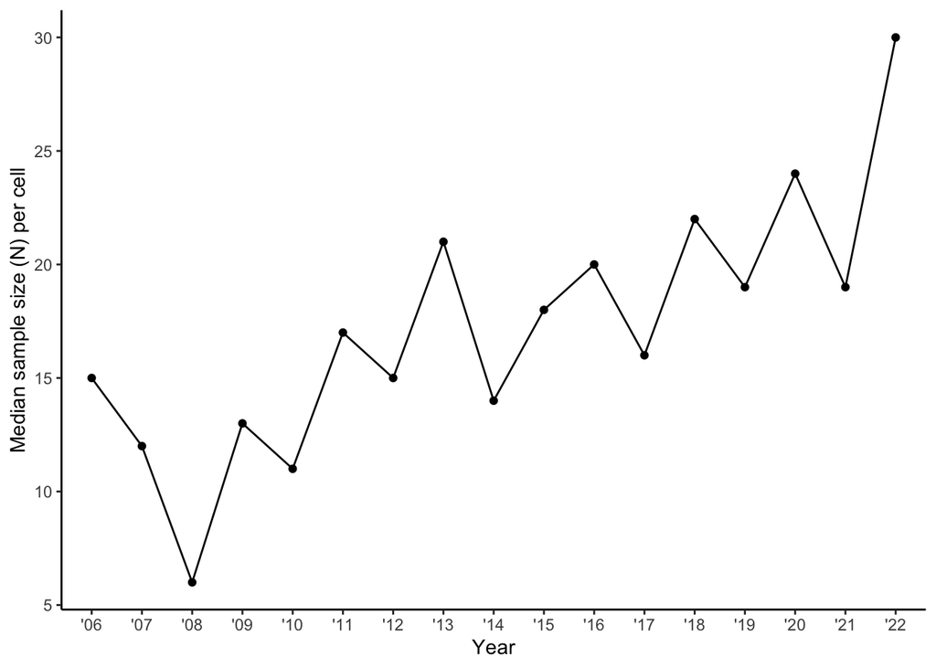

```r
# Filter out non-social studies published in psych science
# calculate median Ns
# order field column by same used in Table 1
data_figure_2 <- data_table_2_filtered |>
  group_by(field, year) |>
  summarize(median_n_per_cell = janitor::round_half_up(median(N_per_cell, na.rm = TRUE), 0)) |>
  ungroup() |>
  mutate(field = fct_rev(fct_relevel(field, levels(data_table_2$field))))

# plot
ggplot(data_figure_2, aes(as.factor(year), median_n_per_cell, group = field)) +
  #geom_smooth(method = "lm") +
  geom_line() +
  geom_point() +
  scale_color_viridis_d(option = "plasma", begin = 0.1, end = 0.9) +
  theme_classic() +
  ylab("Median sample size (N) per cell") +
  xlab("Year")
```

#### Combined

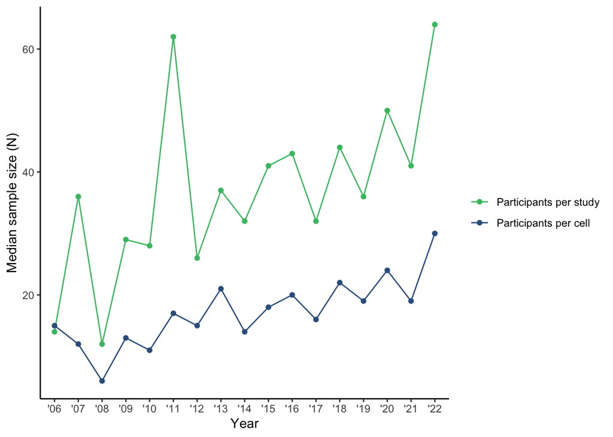

```r
bind_rows(
  data_figure_1 |>
    mutate(type = "Participants per study"),
  data_figure_2 |>
    rename(median_n = median_n_per_cell) |>
    mutate(type = "Participants per cell")
) |>
ggplot(aes(as.factor(year), median_n, group = type, color = type)) +
  #geom_smooth(method = "lm") +
  geom_line() +
  geom_point() +
  scale_color_viridis_d(option = "viridis", begin = 0.3, end = 0.7,
                        guide = guide_legend(reverse = TRUE)) +
  theme_classic() +
  ylab("Median sample size (N)") +
  xlab("Year") +
  labs(colour = "")
```

## Estimated Statistical Power

to Detect an Average Published Effect Size ($\rho$ = .20) over time

### Table

```r
# use median n to calculate power
data_table_3_long <- data_table_2_n_long |>
  #mutate(power = janitor::round_half_up(pwr.r.test(r = .2, sig.level = 0.05, n = median_n_per_cell)$power*100, 0)) |>
  mutate(power = janitor::round_half_up(pwr.t.test(d = .408, sig.level = 0.05, n = median_n_per_cell, type = "two.sample")$power*100, 0)) |>
  select(-median_n_per_cell)

# reshape table, order field column by that used in previous table
data_table_3 <- data_table_3_long |>
  pivot_wider(names_from = year,
              values_from = power) |>
              #names_prefix = "power ") |>
  mutate(field = fct_relevel(field, levels(data_table_1$field))) |>
  arrange(desc(field)) |>
  select(field,
         `'06`, `'07`, `'08`, `'09`, `'10`, `'11`,
         `'12`, `'13`, `'14`, `'15`, `'16`, `'17`,
         `'18`, `'19`, `'20`, `'21`, `'22`)

# print table
data_table_3 |>
  kable() |>
  kable_styling(bootstrap_options = c("striped", "hover", "condensed"), full_width = FALSE)
```

| field | ’06 | ’07 | ’08 | ’09 | ’10 | ’11 | ’12 | ’13 | ’14 | ’15 | ’16 | ’17 | ’18 | ’19 | ’20 | ’21 | ’22 |
| --- | --- | --- | --- | --- | --- | --- | --- | --- | --- | --- | --- | --- | --- | --- | --- | --- | --- |
| IRAP research | 19 | 16 | 10 | 17 | 15 | 21 | 19 | 25 | 18 | 22 | 24 | 20 | 26 | 23 | 28 | 23 | 34 |

### Figure

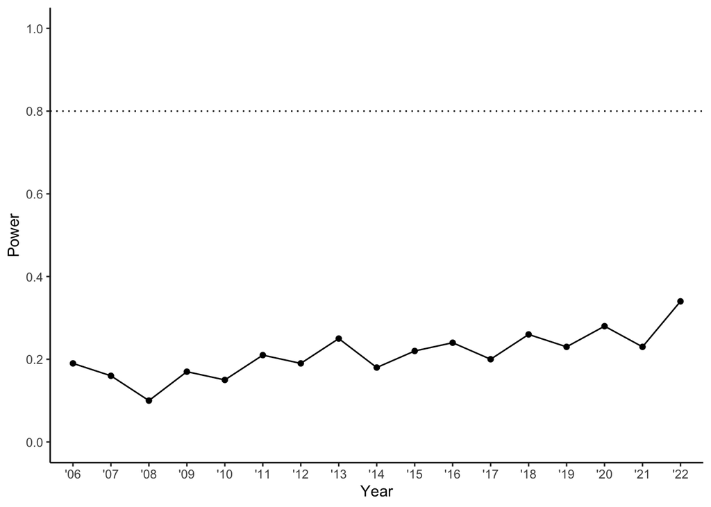

```r
# order field column by same used in Table 1, then plot
data_table_3_long |>
  mutate(field = fct_rev(fct_relevel(field, levels(data_table_1$field)))) |>
  ggplot(aes(as.factor(year), power/100, group = field)) +
  geom_hline(yintercept = .80, linetype = "dotted") +
  geom_line() +
  geom_point() +
  scale_color_viridis_d(option = "plasma", begin = 0.1, end = 0.9) +
  scale_y_continuous(labels = scales::label_comma(),
                     breaks = c(0, .2, .4, .6, .8, 1),
                     limits = c(0,1)) +
  theme_classic() +
  ylab("Power") +
  xlab("Year")
```

## Estimated False-Discovery Rates

### Table

Assuming No p-Hacking or Questionable Research Practices

Using various assumptions about the P(null = TRUE)

```r
# select a subset power data from first and last year studied, reshape
data_power_subset <- data_table_3 |>
  select(field, `'11`, `'19`) |>
  pivot_longer(cols = c(`'11`, `'19`),
               names_to = "year",
               values_to = "power")

# duplicate data with different values of $P(H_0)$,
# calculate False Discovery Rate
data_table_4 <- bind_rows(
  mutate(data_power_subset, baserate_null = .50),
  mutate(data_power_subset, baserate_null = .80)
) |>
  mutate(power = power/100,
         fdr = janitor::round_half_up( (baserate_null*.05) / (  (baserate_null*.05) + ((1-baserate_null)*power)  ), 2)) |>
  select(field, year, baserate_null, fdr) |>
  pivot_wider(names_from = c(year, baserate_null),
              values_from = fdr) |>
  select(field, `'11_0.5`, `'11_0.8`, `'19_0.5`, `'19_0.8`)

# print table
data_table_4 |>
  kable(col.names = c("field", "$P(H_0)$ = 0.5", "$P(H_0)$ = 0.8", "$P(H_0)$ = 0.5", "$P(H_0)$ = 0.8"),
        escape = FALSE) |>
  kable_styling(bootstrap_options = c("striped", "hover", "condensed"), full_width = FALSE) %>%
  add_header_above(c(" " = 1, "2011" = 2, "2019" = 2))
```

| field | 2011 $P(H_0)$ = 0.5 | 2011 $P(H_0)$ = 0.8 | 2019 $P(H_0)$ = 0.5 | 2019 $P(H_0)$ = 0.8 |
| --- | --- | --- | --- | --- |
| IRAP research | 0.19 | 0.49 | 0.18 | 0.47 |

# IRAP vs Social Psychology studies using study N (after exclusions)

More assumptions by using sample size N rather than N per cell.

## Change in N-pact over time

Results represent Median N (k studies)

### Table

```r
# Filter out non-social studies published in psych science
data_table_5_filtered <- data_combined |>
  filter(
    (design == "between" &
      ((journal == "PS:S" & (social_ps == 1 | is.na(social_ps))) | journal != "PS:S")) |
      (journal == "IRAP" & design %in% c("between", "mixed"))
  )

# calculate median N for each field and year
# round using typical half-up rule and not R's weird rounding
data_table_5_n_long <- data_table_5_filtered |>
  group_by(field, year) |>
  summarize(median_n = janitor::round_half_up(median(N, na.rm = TRUE), 0)) |>
  ungroup()

# Calculate median median n for each field
data_table_5_n_aggregate <- data_table_5_n_long |>
  group_by(field) |>
  summarize(median_median_n = median(median_n, na.rm = TRUE)) |>
  ungroup()

# Calculate k studies used to calculate median ns
data_table_5_k_long <- data_table_5_filtered |>
  count(field, year, name = "k_studies")

# combine Ns and Ks, reshape, and order field column by aggregate median median n
data_table_5 <-
  full_join(data_table_5_n_long, data_table_5_k_long, by = c("field", "year")) |>
  mutate(result = paste0(median_n, " (", k_studies, ")")) |>
  select(-median_n, -k_studies) |>
  pivot_wider(names_from = year,
              values_from = result) |>
              #names_prefix = "NF ") |>
  left_join(data_table_5_n_aggregate, by = "field") |>
  mutate(field = fct_reorder(field, median_median_n)) |>
  arrange(desc(field)) |>
  select(field, median_median_n,
         `'06`, `'07`, `'08`, `'09`, `'10`, `'11`,
         `'12`, `'13`, `'14`, `'15`, `'16`, `'17`,
         `'18`, `'19`, `'20`, `'21`, `'22`)

# print table
data_table_5 |>
  select(field,
         Aggregate = median_median_n,
         starts_with("'")) |>
         #starts_with("NF")) |>
  kable() |>
  kable_styling(bootstrap_options = c("striped", "hover", "condensed"), full_width = FALSE)
```

| field | Aggregate | ’06 | ’07 | ’08 | ’09 | ’10 | ’11 | ’12 | ’13 | ’14 | ’15 | ’16 | ’17 | ’18 | ’19 | ’20 | ’21 | ’22 |
| --- | --- | --- | --- | --- | --- | --- | --- | --- | --- | --- | --- | --- | --- | --- | --- | --- | --- | --- |
| Social Psychology | 153 | NA | NA | NA | NA | NA | 103 (314) | 98 (304) | 130 (316) | 124 (297) | 153 (390) | 156 (327) | 221 (344) | 227 (402) | 251 (353) | NA | NA | NA |
| IRAP research | 41 | 44 (1) | 36 (1) | 12 (2) | 26 (9) | 22 (6) | 64 (3) | 30 (3) | 41 (5) | 36 (8) | 43 (12) | 48 (22) | 32 (11) | 49 (9) | 46 (10) | 53 (12) | 37 (7) | 64 (5) |

### Figure

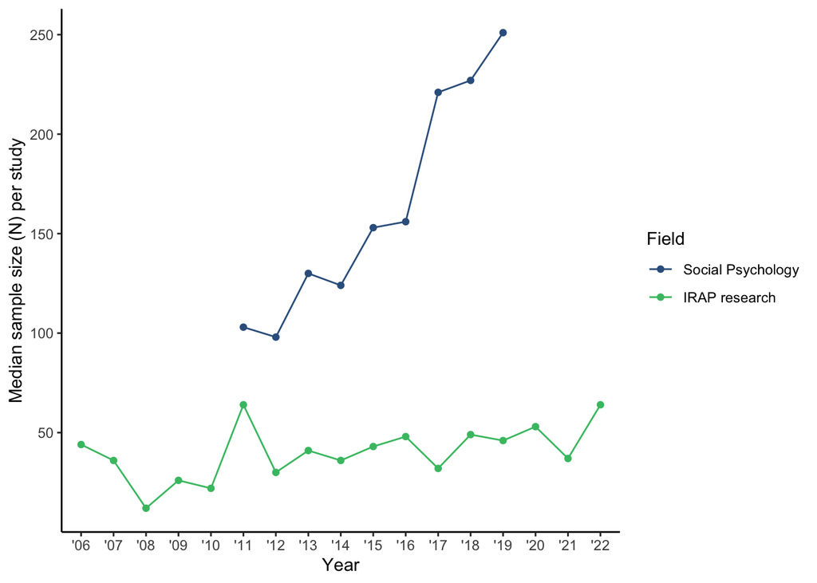

```r
# Filter out non-social studies published in psych science
# calculate median Ns
# order field column by same used in Table 1
data_figure_4 <- data_table_5_filtered |>
  group_by(field, year) |>
  summarize(median_n = janitor::round_half_up(median(N, na.rm = TRUE), 0)) |>
  ungroup() |>
  mutate(field = fct_rev(fct_relevel(field, levels(data_table_1$field))))

# plot
ggplot(data_figure_4, aes(as.factor(year), median_n, color = field, group = field)) +
  #geom_vline(xintercept = "2011", linetype = "dotted") +
  #geom_smooth(method = "lm", alpha = 0.2) +
  geom_line() +
  geom_point() +
  scale_y_continuous(breaks = c(0, 50, 100, 150, 200, 250, 300)) +
  scale_color_viridis_d(option = "viridis", begin = 0.3, end = 0.7) +
  theme_classic() +
  ylab("Median sample size (N) per study") +
  xlab("Year") +
  labs(colour = "Field")
```

## Estimated statistical power

to Detect an Average Published Effect Size ($\rho$ = .20) over time

### Table

```r
# use median n to calculate power
data_table_6_long <- data_table_5_n_long |>
  mutate(power = janitor::round_half_up(pwr.r.test(r = .2, sig.level = 0.05, n = median_n)$power*100, 0)) |>
  select(-median_n)

# reshape table, order field column by that used in previous table
data_table_6 <- data_table_6_long |>
  pivot_wider(names_from = year,
              values_from = power) |>
              #names_prefix = "power ") |>
  mutate(field = fct_relevel(field, levels(data_table_1$field))) |>
  arrange(desc(field)) |>
  select(field,
         `'06`, `'07`, `'08`, `'09`, `'10`, `'11`,
         `'12`, `'13`, `'14`, `'15`, `'16`, `'17`,
         `'18`, `'19`, `'20`, `'21`, `'22`)

# print table
data_table_6 |>
  kable() |>
  kable_styling(bootstrap_options = c("striped", "hover", "condensed"), full_width = FALSE)
```

| field | ’06 | ’07 | ’08 | ’09 | ’10 | ’11 | ’12 | ’13 | ’14 | ’15 | ’16 | ’17 | ’18 | ’19 | ’20 | ’21 | ’22 |
| --- | --- | --- | --- | --- | --- | --- | --- | --- | --- | --- | --- | --- | --- | --- | --- | --- | --- |
| Social Psychology | NA | NA | NA | NA | NA | 53 | 51 | 63 | 61 | 70 | 71 | 85 | 86 | 89 | NA | NA | NA |
| IRAP research | 26 | 22 | 10 | 17 | 15 | 36 | 19 | 24 | 22 | 25 | 28 | 20 | 28 | 27 | 30 | 22 | 36 |

### Figure

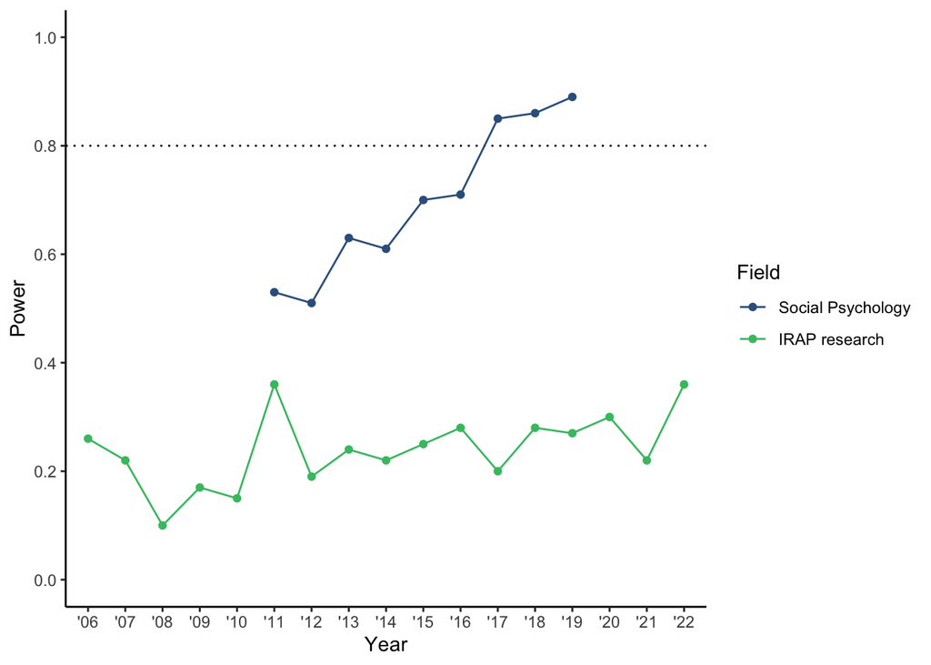

```r
# order field column by same used in Table 1, then plot
data_table_6_long |>
  mutate(field = fct_rev(fct_relevel(field, levels(data_table_1$field)))) |>
  ggplot(aes(as.factor(year), power/100, color = field, group = field)) +
  geom_hline(yintercept = .80, linetype = "dotted") +
  geom_line() +
  geom_point() +
  scale_color_viridis_d(option = "viridis", begin = 0.3, end = 0.7) +
  theme_classic() +
  ylab("Power") +
  xlab("Year") +
  labs(colour = "field") +
  scale_y_continuous(labels = scales::label_comma(),
                     breaks = c(0, .2, .4, .6, .8, 1),
                     limits = c(0,1)) +
  labs(colour = "Field")
```

## Estimated False-Discovery Rates

Assuming No p-Hacking or Questionable Research Practices

Using various assumptions about the P(null = TRUE)

### Table

```r
# select a subset power data from first and last year studied, reshape
data_power_subset <- data_table_6 |>
  select(field, `'11`, `'19`) |>
  pivot_longer(cols = c(`'11`, `'19`),
               names_to = "year",
               values_to = "power")

# duplicate data with different values of $P(H_0)$,
# calculate False Discovery Rate
data_table_7 <- bind_rows(
  mutate(data_power_subset, baserate_null = .50),
  mutate(data_power_subset, baserate_null = .80)
) |>
  mutate(power = power/100,
         fdr = janitor::round_half_up( (baserate_null*.05) / (  (baserate_null*.05) + ((1-baserate_null)*power)  ), 2)) |>
  select(field, year, baserate_null, fdr) |>
  pivot_wider(names_from = c(year, baserate_null),
              values_from = fdr) |>
  select(field, `'11_0.5`, `'11_0.8`, `'19_0.5`, `'19_0.8`)

# print table
data_table_7 |>
  kable(col.names = c("field", "$P(H_0)$ = 0.5", "$P(H_0)$ = 0.8", "$P(H_0)$ = 0.5", "$P(H_0)$ = 0.8"),
        escape = FALSE) |>
  kable_styling(bootstrap_options = c("striped", "hover", "condensed"), full_width = FALSE) %>%
  add_header_above(c(" " = 1, "2011" = 2, "2019" = 2))
```

| field | 2011 $P(H_0)$ = 0.5 | 2011 $P(H_0)$ = 0.8 | 2019 $P(H_0)$ = 0.5 | 2019 $P(H_0)$ = 0.8 |
| --- | --- | --- | --- | --- |
| Social Psychology | 0.09 | 0.27 | 0.05 | 0.18 |
| IRAP research | 0.12 | 0.36 | 0.16 | 0.43 |